# Basicos de R

# RStudio

RStudio es un ambiente de desarrollo integrado para programar en R

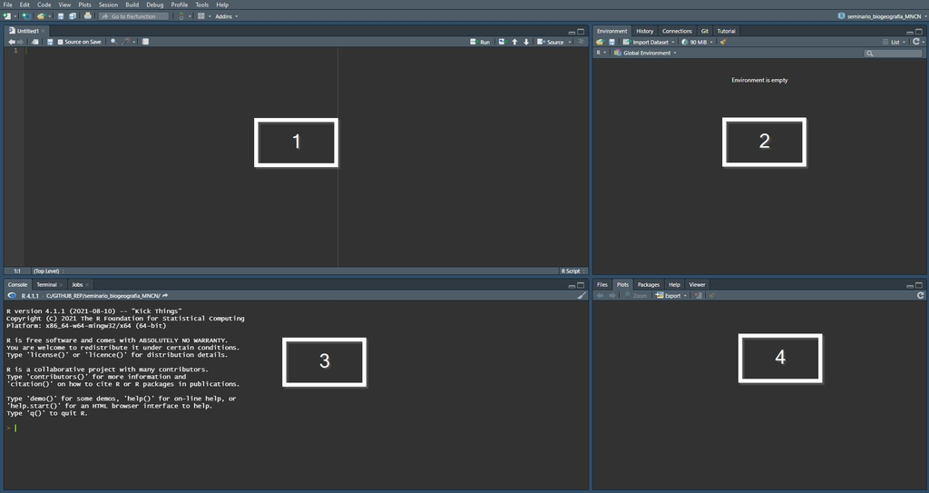

*Zona 1: Editor*  
Es la zona de trabajo en la que se escribe el código que se querrá ejecutar.  
Para ejecutar el código `Ctrl + Enter`.  
Para indicar que es un comentario y no es código `#`.  
*Zona 2: Entorno de trabajo*  
Se muestran todos los objetos creados. Para crear un objeto `<-`.  
*Zona 3: Consola y Terminal*  
Aquí se ejecuta el codigo. Al ejecutar el codigo `Ctrl + Enter` del editor este pasa a la consola. Se muestran los avisos y errores.  
*Zona 4: Archivos, Plots, Librerías, Ayuda y Visor*  
Varias pestañas: – En Files encontraras los archivos que se encuentren en la carpeta que tengas seleccionada. Podrás moverte por las carpetas de tu sistemas operativo, así como copiar, borrar u otras operaciones.  
– En Plots te aparecerán los gráficos que quieras pintar en tus scripts.  
– En Packages, podrás acceder a ver, actualizar, eliminar o descargar paquetes.  
– En Help aparecerá la ayuda de R base.  
– En Viewer se abrirán imágenes, que no gráficos.

Más información: https://posit.co/wp-content/uploads/2022/10/rstudio-ide-1.pdf

# Directorio de trabajo en R

El directorio de trabajo en R es la carpeta donde se está trabajando. Por lo tanto, es el lugar (el entorno) donde debe almacenar los archivos de su proyecto para poder cargarlos o donde se guardarán sus objetos R.  
Es importante señalar que las rutas en R se hacen indican con `/`.

**Obtener la ruta del directorio de trabajo**

```r
getwd()
```

**Modificar la ruta del directorio de trabajo**  
Se puede hacer de manera manual `Ctrl + Shift + H` o mediante código.

```r
setwd("C:/NUEVO_DIRECTORIO")
```

Más Información: https://r-coder.com/working-directory-r/

# Instalación de paquetes R

Un paquete R es una biblioteca de funciones

**Instalar paquetes desde CRAN (Comprehensive R Archive Network), el repositorio oficial de paquetes R**  
Se puede hacer de manera manual `Tools`- `Install Packages`.

```r
install.packages("ggplot")
```

Después de la instalación, hay que cargar el paquete con la función `library`.

```r
library("ggplot")
```

Más Información: https://r-coder.com/install-r-packages/

# Ayuda en R

**Ayuda inicial**

```r
help.start()
```

**Ayuda de una función o paquete conociendo el nombre exacto**

```r
?ggplot
```

**Ayuda de una función o paquete sin conocer el nombre exacto**

```r
??ggpl
```

# Viñeta de ejemplos

Las viñetas son largas guías de paquetes que describen su uso con amplias explicaciones y ejemplos

```r
vignette("extending-ggplot2")
```

Más Información:https://r-coder.com/help-r/

# Tipo de datos en R

### Vector

Los vectores son la estructura de datos más básica en R. Estas estructuras permiten concatenar datos.

```r
numeros <- c(1, 2, 3)
caracteres <- c("a","b", "AbC")
vector <- c(1, "ae", "2a")
```

```r
numeros
```

```
## [1] 1 2 3
```

```r
caracteres
```

```
## [1] "a"   "b"   "AbC"
```

```r
vector
```

```
## [1] "1"  "ae" "2a"
```

**Conocer el tipo de vector**

```r
class(numeros)
```

```
## [1] "numeric"
```

```r
class(caracteres)
```

```
## [1] "character"
```

```r
class(vector)
```

```
## [1] "character"
```

**Conocer la longitud del vector**

```r
length(vector)
```

```
## [1] 3
```

**Acceder a elementos de vectores**

```r
vector[3]
```

```
## [1] "2a"
```

Más información: https://r-coder.com/vector-r/

### Marco de datos en R

Los marcos de datos mas conocidos como dataframes son el objeto más habitual para almacenar datos en R. Este tipo de objeto está formado por filas y columnas.

**Crear marco de datos vacío**

```r
marco_datos <- data.frame(Nombre = character(),
                          Edad = numeric())
```

**Añadir datos al marco de datos vacío**

```r
marco_datos[1,1] <- "Mario"
marco_datos[1,2] <- 12
marco_datos[2,1] <- "Maria"
marco_datos[2,2] <- 21
marco_datos
```

```
##   Nombre Edad
## 1  Mario   12
## 2  Maria   21
```

**Añadir y modificar datos un marco de datos**  
La funcion `cbin` añade una nueva columna.

```r
peso <- c(10,16)
marco_datos <- cbind(marco_datos, peso)
```

La función `rbind` añade una nueva fila.

```r
marco_datos <- rbind(marco_datos, c("Marie", 22, 15))
```

```r
marco_datos
```

```
##   Nombre Edad peso
## 1  Mario   12   10
## 2  Maria   21   16
## 3  Marie   22   15
```

La función `colnames` modifica los nombres de las columnas.

```r
colnames(marco_datos) <- c("Columna_1", "Columna_2", "Columna_3")
```

La función `rownames` modifica los nombres de las filas.

```r
rownames(marco_datos)<- c("Fila_1", "Fila_2", "Fila_3")
```

```r
marco_datos
```

```
##        Columna_1 Columna_2 Columna_3
## Fila_1     Mario        12        10
## Fila_2     Maria        21        16
## Fila_3     Marie        22        15
```

**Acceder a los datos del marco de datos**  
Las posiciones del marco de datos se indican con los corchetes `[]`.  
La fila se indica antes de la coma `[fila , ]`.  
La columna se indica después de la coma `[ , columna]`.

```r
marco_datos[1,1]     # Fila 1 y columna 1
```

```
## [1] "Mario"
```

```r
marco_datos[1, ]     # Fila 1 todas las columnas
```

```
##        Columna_1 Columna_2 Columna_3
## Fila_1     Mario        12        10
```

```r
marco_datos[ ,2]     # Todas las filas y columna 2
```

```
## [1] "12" "21" "22"
```

**Exportar los datos**  
Utilizar la función `write_xlsx` del paquete `writexl`.

```r
library(writexl)
write_xlsx(marco_datos, "C:/DIRECTORIO/excel.xlsx" )
```

**Cargar datos** Utilizar la función `read_xlsx` del paquete `readxl`.

```r
library(readxl)
marco_datos <- read_xlsx("C:/DIRECTORIO/excel.xlsx")
```

Añadir datos de manera manual: https://cran.r-project.org/web/packages/editData/readme/README.html

Más información: https://r-coder.com/dataframe-r/

### Materiales de aprendizaje

R for data science: https://r4ds.had.co.nz/index.html en español https://es.r4ds.hadley.nz/  
YaRrr! The Pirate’s Guide to R: https://bookdown.org/ndphillips/YaRrr/  
R for Data Analysis: https://trevorfrench.github.io/R-for-Data-Analysis/  
Más recursos: https://www.learnr4free.com/es/index.html  
Libros y más libros: https://libgen.is/